# a2_task2_kat_leigh

Kat Leigh

1/31/2021

# Exploring two palmetto plant species with binary logistic regression.

Using binary logistic regression to test feasibility of using variables plant height (height), canopy length (length), canopy width (width), and number of green leaves (green_lvs) to classify whether a palmetto is species Serenoa repens or Sabal etonia.

Data source: Abrahamson, W.G. 2019. Survival, growth and biomass estimates of two dominant palmetto species of south-central Florida from 1981 - 2017, ongoing at 5-year intervals ver 1. Environmental Data Initiative. https://doi.org/10.6073/pasta/f2f96ec76fbbd4b9db431c79a770c4d5

More information and metadata: https://portal.edirepository.org/nis/metadataviewer?packageid=edi.317.1

Start by examining the data roughly.

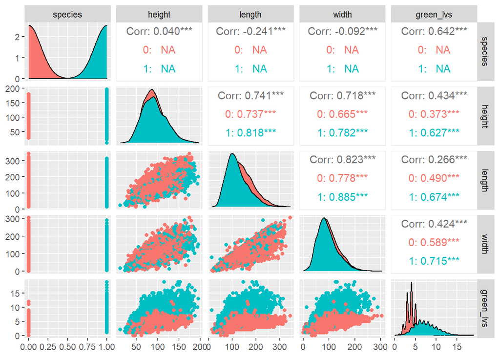

```r
# read in data

palmetto_n <- read_csv("palmetto.csv") %>% clean_names() %>%
  select(height, length, width, green_lvs, species, plant) %>%
  mutate(species = ifelse(species == 1, 1,
                          ifelse(species == 2, 0, 2)))

palmetto_w <- palmetto_n %>%
  mutate(species = ifelse(species == 1, "Serenoa repens",
                          ifelse(species == 0, "Sabal etonia", 0))) %>%
  group_by(species) %>%
  pivot_longer(cols = c(height:green_lvs), names_to = "measurement", values_to = "value") %>%
  mutate(measurement = as.factor(measurement)) %>% ungroup()

# look at data
look <- palmetto_n %>%
  select(species, height:green_lvs) %>%
  ggpairs(aes(color = as.factor(species)))

look
```

The exploratory graphs seem to indicate some potential trends, depicted more formally below.

[figure not shown]

```r
# generate some nice figures based off the findings in look

levels(palmetto_w$measurement) <- c("height (cm)", "canopy length (cm)","canopy width (cm)", "green leaves (count)")

p_1 <- ggplot(drop_na(palmetto_w))+
  geom_violin(aes(x = species, y = value, color = measurement))+theme_minimal()+facet_wrap(~measurement, labeller = labeller(levels(palmetto_w$measurement)), scales = "free_y")+
  labs(title = "distribution of various palmeto parameters by species",
       caption = str_wrap("Measurements for two species of palmeto. 12460 values recorded for each parameter.", 90),
       x = "Species",
       y = "Value")

p_1
```

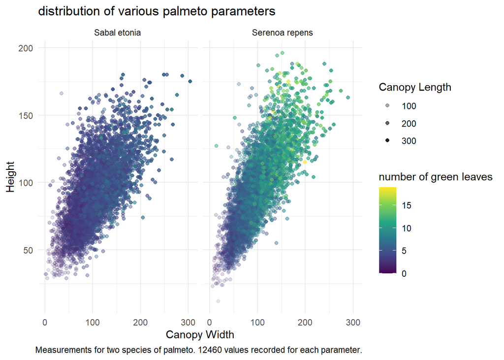

```r
palmetto_ng <- palmetto_n %>%
  mutate(species = ifelse(species == 1, "Serenoa repens",
                          ifelse(species == 0, "Sabal etonia", 0)))

p_2 <- ggplot(drop_na(palmetto_ng))+
  geom_point(aes(x = width, y = height, color = green_lvs, alpha = length))+ facet_wrap(~species)+theme_minimal()+
  labs(title = "distribution of various palmeto parameters",
       caption = str_wrap("Measurements for two species of palmeto. 12460 values recorded for each parameter.", 90),
       x = "Canopy Width",
       y = "Height",
       color = "number of green leaves",
       alpha = "Canopy Length")+
  scale_color_viridis_c()

p_2
```

It’s hard to tell if any of these parameters can clearly distinguish one species from another, but possibly a linear model can help! It seems like number of green leaves might be a good differentiating parameter.